# Data visualization with ggplot2

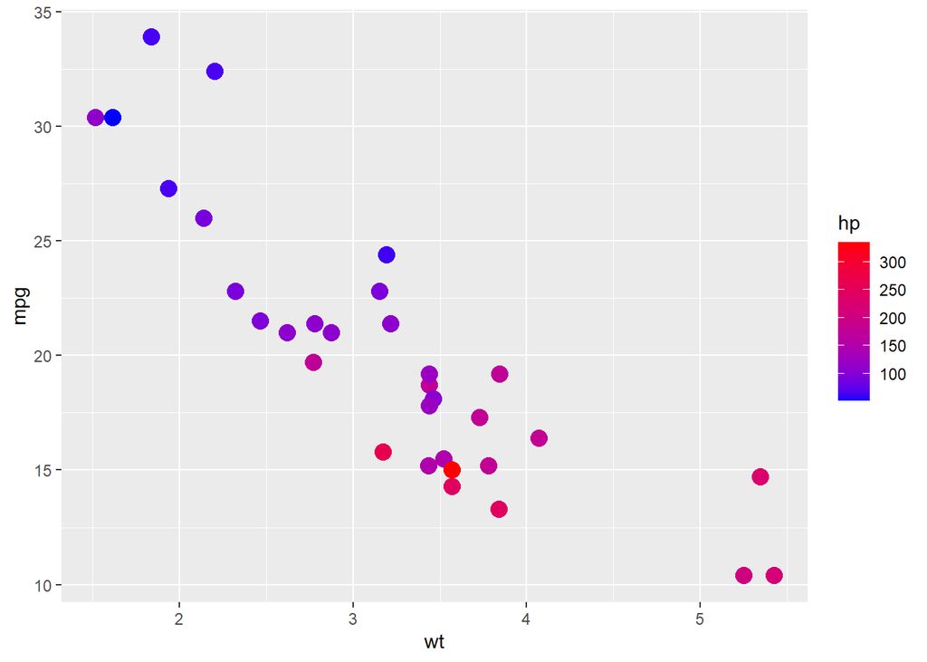

```r
pl + geom_point(aes(colour = hp),size=4) + scale_colour_gradient(high='red',low = "blue")
```

*Coordinates and Faceting with ggplot2*  
Learning how to deal with coordinates will allow us to size our plots correctly. Faceting will allow us to place several plots next to each other, these plots are usually related by the same dataset.

```r
library(ggplot2)
pl <- ggplot(mpg,aes(x=displ,y=hwy)) + geom_point()
```

*Setting x and y limits*  
You can use + scale_x_continuous and scale_y_continuous with an additional limits=c(low,high) argument to set the scale. A sometimes nicer way to do this is by adding + coord_cartesian() with xlim and ylim arguments and pass in numeric vectors

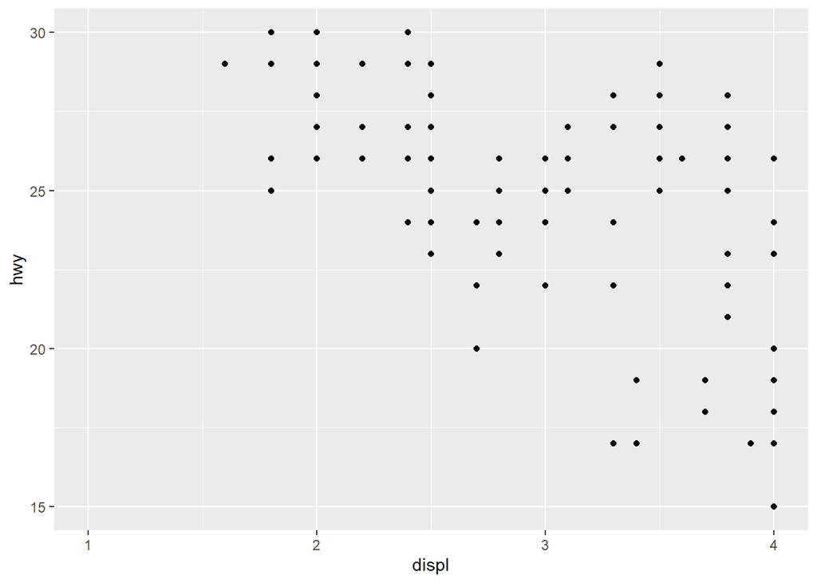

```r
pl + coord_cartesian(xlim=c(1,4),ylim=c(15,30))
```

*Aspect Ratios* You can use the coord_fixed() method to change the aspect ratio of a plot (default is 1:1)

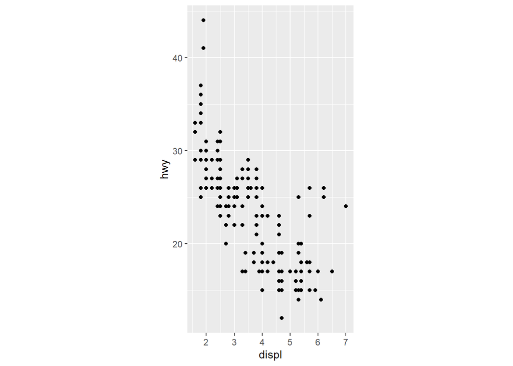

```r
# aspect ratio, expressed as y / x
pl + coord_fixed(ratio = 1/3)
```

*Facets*  
The best way to set up a facet grid (multiple plots) is to use facet_grid(), the main part of this function is the use of the facet argument:

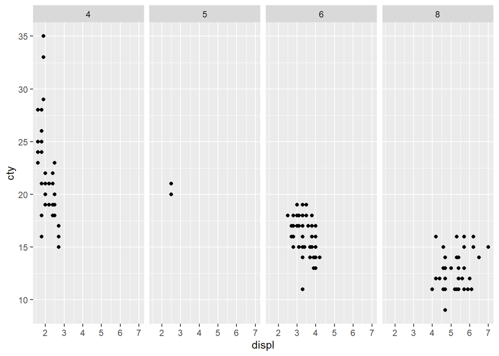

```r
p <- ggplot(mpg, aes(displ, cty)) + geom_point()

p + facet_grid(. ~ cyl)
```

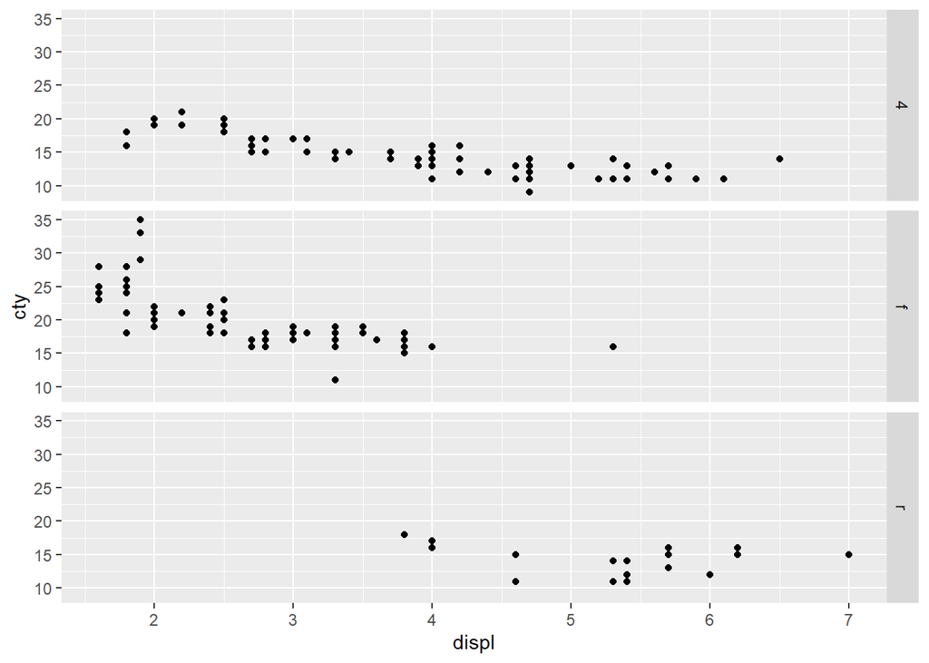

```r
p + facet_grid(drv ~ .)
```

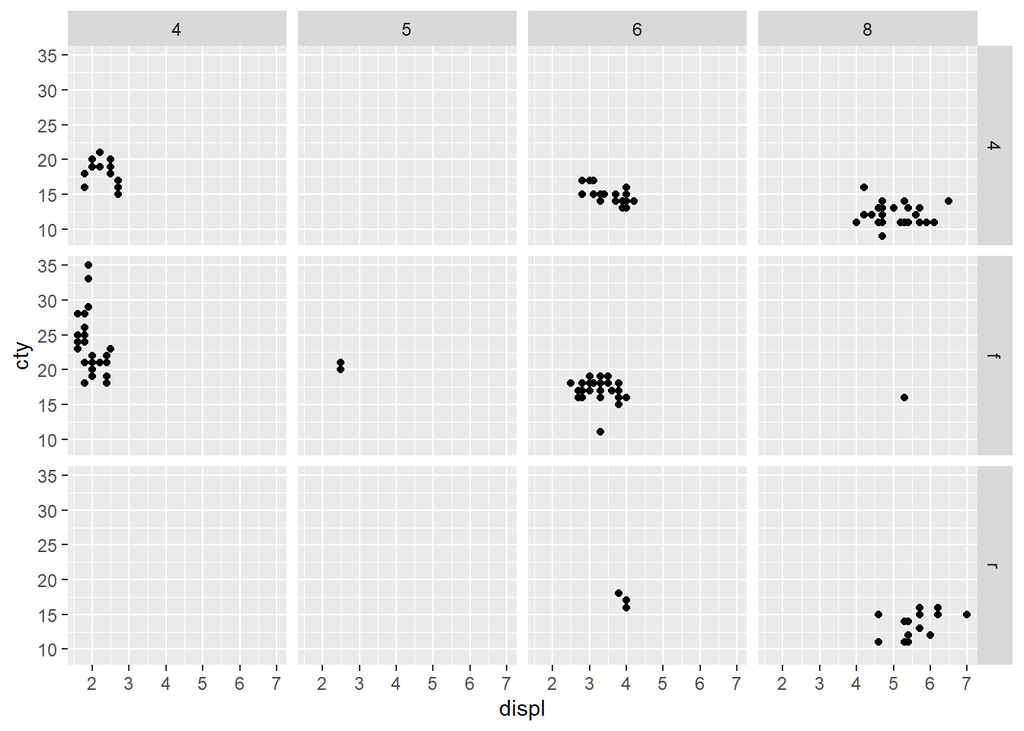

```r
p + facet_grid(drv ~ cyl)
```

*Themes*  
There is also a great library called ggthemes which adds even more built-in themes for ggplot. You can also customize your own themes.

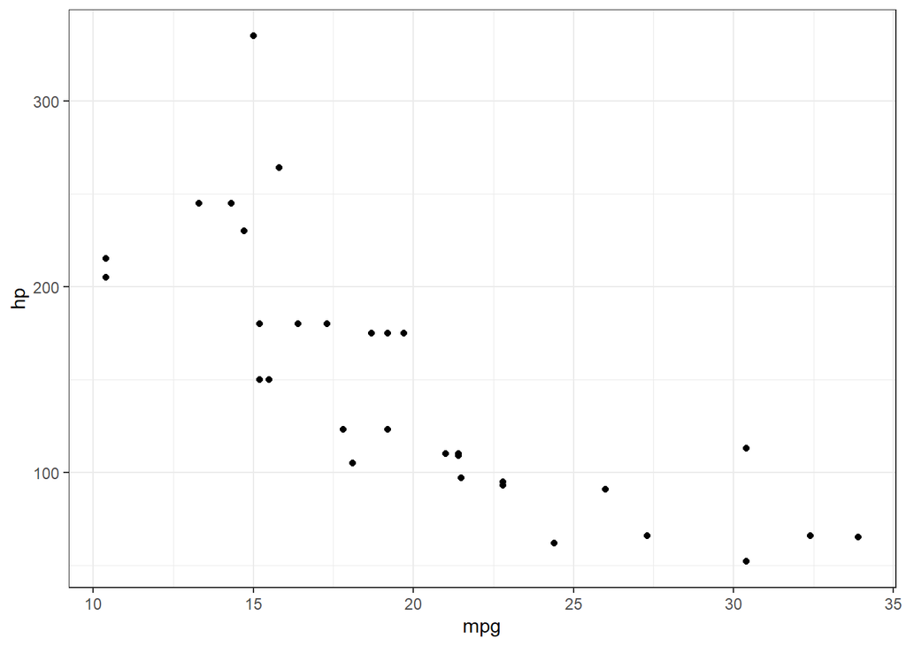

```r
df <- mtcars
pl <- ggplot(df,aes(x=mpg,y=hp)) + geom_point()
pl + theme_bw()
```

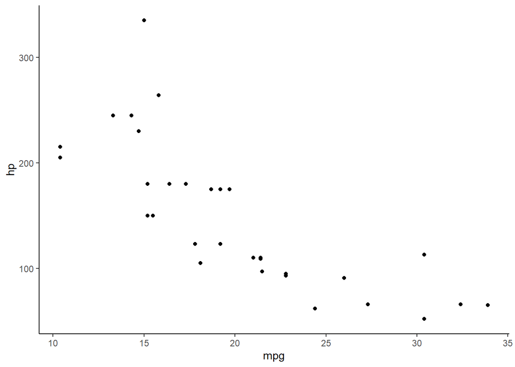

```r
pl + theme_classic()
```

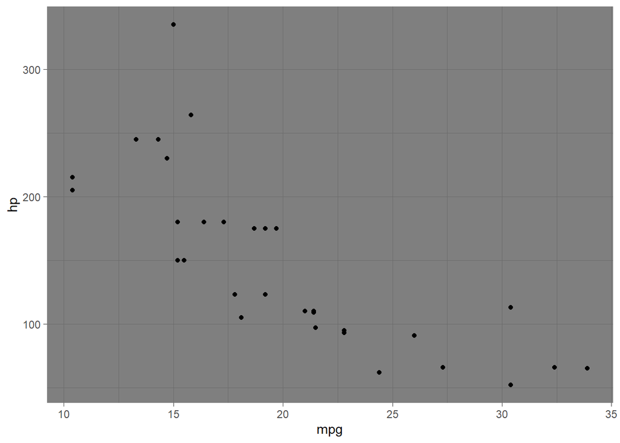

```r
pl + theme_dark()
```

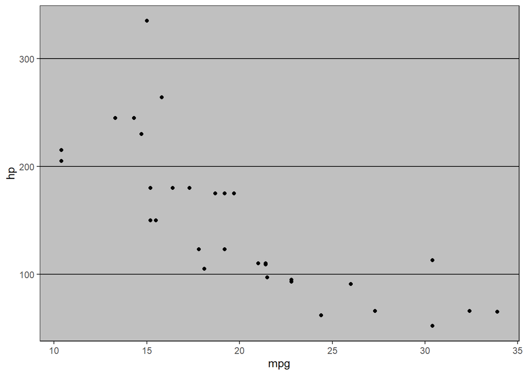

```r
library(ggthemes)
pl + theme_excel()
```

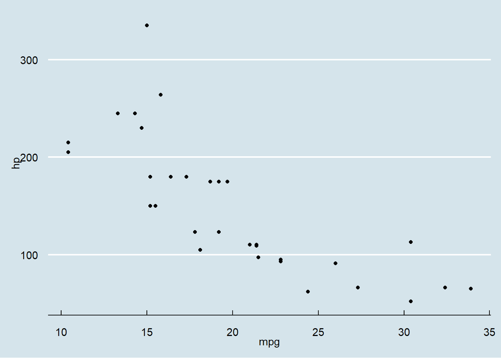

```r
pl + theme_economist()
```

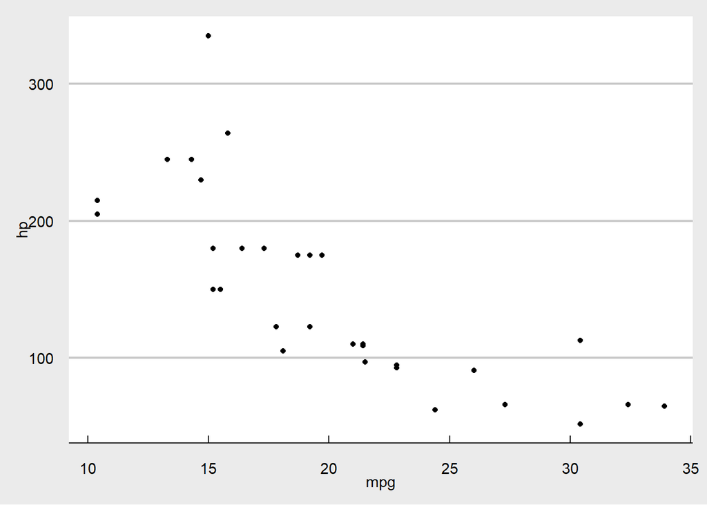

```r
pl + theme_economist_white()
```

*2 Variable Plotting with ggplot2* In this lecture we will briefly see some examples of how you can compare two variables from a dataset.

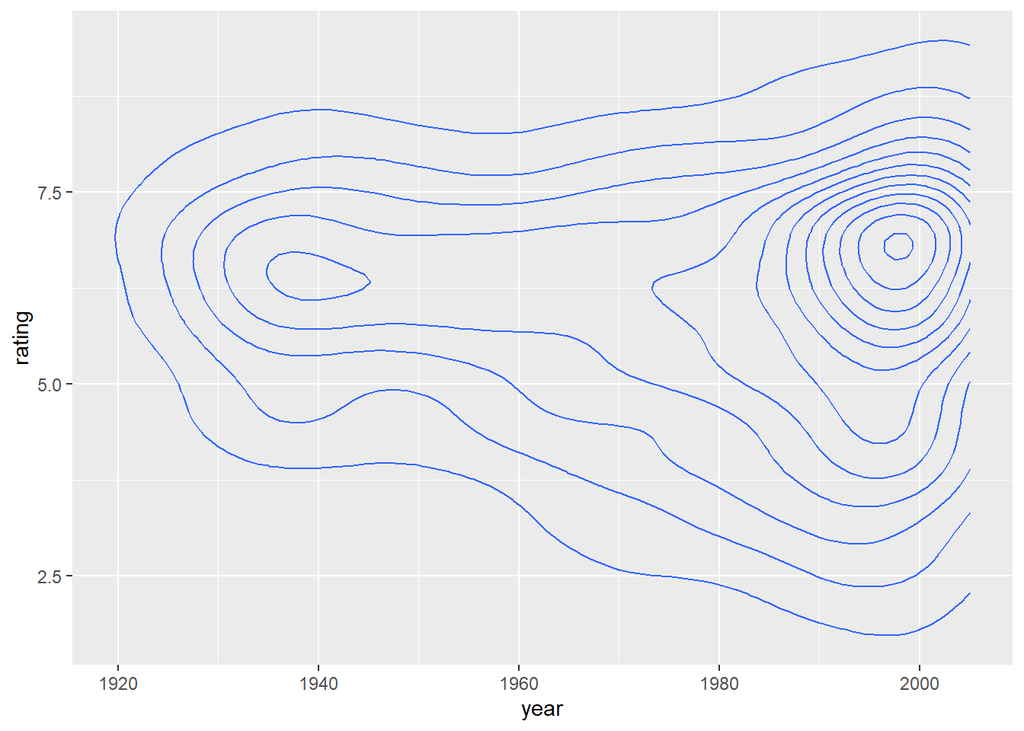

```r
library(ggplot2)
df <- movies
qplot(x=year, y=rating, data = df, geom = "density2d")
```

```r
pl <- ggplot(movies,aes(x = year,y=rating))
```

2d Bin Chart

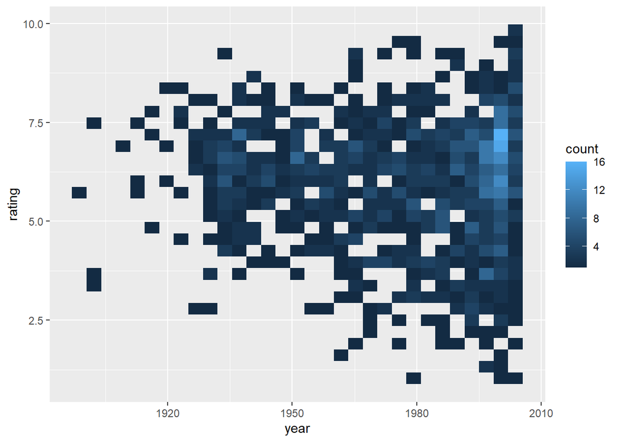

```r
pl + geom_bin2d()
```

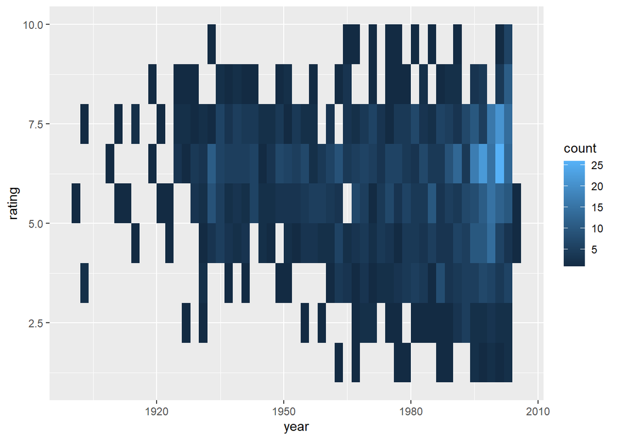

```r
# Control bin sizes
pl + geom_bin2d(binwidth=c(2,1))
```

2d Density Plot

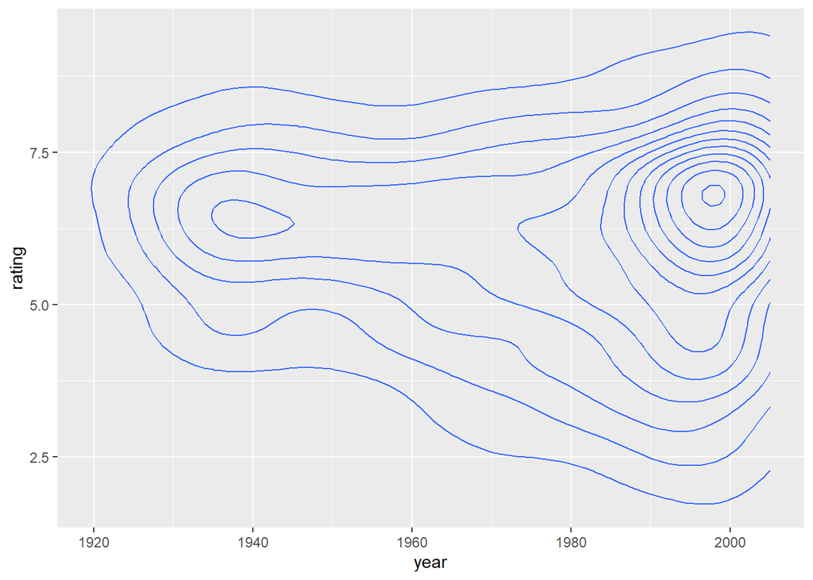

```r
pl + geom_density2d()
```

2d Hex Plot

[figure not shown]

```r
pl + geom_hex()
```

[figure not shown]

```r
pl + geom_hex() + scale_fill_gradient(high='red',low='blue')
```